# PCA_ejemplo2

```python
import numpy as np
import matplotlib.pyplot as plt
```

## Ejemplo: Eigenfaces

Aquí exploramos un ejemplo del uso de una proyección de PCA como selector de características para el reconocimiento facial con una máquina de vectores de soporte. Aquí vamos a echar un vistazo atrás y explorar un poco más de lo que pasó en eso. Recuerde que estábamos utilizando las Caras etiquetadas en el conjunto de datos Wild disponible a través de Scikit-Learn:

```python
from sklearn.datasets import fetch_lfw_people
faces = fetch_lfw_people(min_faces_per_person=60)
print(faces.target_names)
print(faces.images.shape)
```

```
['Ariel Sharon' 'Colin Powell' 'Donald Rumsfeld' 'George W Bush'
 'Gerhard Schroeder' 'Hugo Chavez' 'Junichiro Koizumi' 'Tony Blair']
(1348, 62, 47)
```

Echemos un vistazo a los ejes principales que abarcan este conjunto de datos. Debido a que este es un conjunto de datos grande, usaremos el estimador estándar de `PCA` útil para Datos tridimensionales (aquí, una dimensionalidad de casi 3,000). Vamos a echar un vistazo a los primeros 150 componentes:

```python
from sklearn.decomposition import PCA
pca = PCA(150)
pca.fit(faces.data)
```

```
PCA(copy=True, iterated_power='auto', n_components=150, random_state=None,
  svd_solver='auto', tol=0.0, whiten=False)
```

En este caso, puede ser interesante visualizar las imágenes asociadas con los primeros componentes principales (estos componentes se conocen técnicamente como "vectores propios") por lo que estos tipos de imágenes a menudo se denominan "interfaces propias"). Como puedes ver en esta figura, son tan espeluznantes como suenan:

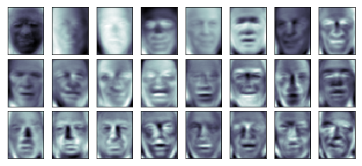

```python
fig, axes = plt.subplots(3, 8, figsize=(9, 4),
                         subplot_kw={'xticks':[], 'yticks':[]},
                         gridspec_kw=dict(hspace=0.1, wspace=0.1))
for i, ax in enumerate(axes.flat):
    ax.imshow(pca.components_[i].reshape(62, 47), cmap='bone')
```

Los resultados son muy interesantes y nos dan una idea de cómo varían las imágenes: por ejemplo, las primeras interfaces propias (desde la parte superior izquierda) parecen estar asociadas con el ángulo de iluminación de la cara, y luego los vectores principales parecen estar recogiendo Por ciertos rasgos, como ojos, narices y labios. Echemos un vistazo a la varianza acumulada de estos componentes para ver cuánta información de datos conserva la proyección:

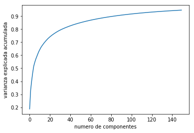

```python
plt.plot(np.cumsum(pca.explained_variance_ratio_))
plt.xlabel('numero de componentes')
plt.ylabel('varianza explicada acumulada');
```

Vemos que estos 150 componentes representan poco más del 90% de la variación. Eso nos llevaría a creer que al usar estos 150 componentes, recuperaríamos la mayoría de las características esenciales de los datos. Para hacer esto más concreto, podemos comparar las imágenes de entrada con las imágenes reconstruidas a partir de estos 150 componentes:

```python
# Calcular los PCA y caras proyectadas
pca = PCA(150).fit(faces.data)
components = pca.transform(faces.data)
projected = pca.inverse_transform(components)
```

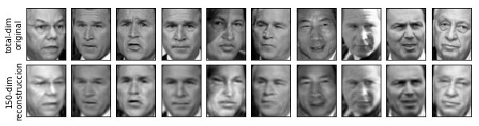

```python
# Plot de los resultados
fig, ax = plt.subplots(2, 10, figsize=(10, 2.5),
                       subplot_kw={'xticks':[], 'yticks':[]},
                       gridspec_kw=dict(hspace=0.1, wspace=0.1))
for i in range(10):
    ax[0, i].imshow(faces.data[i].reshape(62, 47), cmap='binary_r')
    ax[1, i].imshow(projected[i].reshape(62, 47), cmap='binary_r')

ax[0, 0].set_ylabel('total-dim\noriginal')
ax[1, 0].set_ylabel('150-dim\nreconstruccion');
```

La fila superior aquí muestra las imágenes de entrada, mientras que la fila inferior muestra la reconstrucción de las imágenes de solo 150 de las ~ 3,000 características iniciales. Esta visualización deja en claro por qué la selección de funciones de PCA utilizada con SVM fue tan exitosa: aunque reduce la dimensionalidad de los datos en casi un factor de 20, Las imágenes proyectadas contienen suficiente información para que podamos, a simple vista, reconocer a los individuos en la imagen. Lo que esto significa es que nuestro algoritmo de clasificación debe estar capacitado en datos de 150 dimensiones en lugar de datos de 3000 dimensiones, que, dependiendo del algoritmo particular que elijamos, puede llevar a una clasificación mucho más eficiente.